# Flood Inundation Modeling in Calgary and a Comparable City, Ottawa, Ontario

CPLN 6750 Midterm Assignment

Elaina Geiger and Isabel Mulay

04/08/2024

# Introduction

Urban planners and decision-makers are increasingly recognizing the need for predictive models to assess the risk of flood inundation, especially in populated urban areas. These models aim to identify areas prone to flooding, which planners can refer to when implementing mitigation strategies to bolster preparedness for potential flood events. This proactive approach allows cities to allocate resources efficiently, prioritize infrastructure improvements, and minimize the impact of flooding on communities and the environment.

Unlike some more comprehensive methods that may incorporate a broader array of environmental and hydrological factors, such as rainfall intensity, soil infiltration capacity, and river discharge dynamics, our modeling approach focuses on a subset of key variables. Our selection of these variables was informed by qualitative research, where we examined commonalities among historic flood events. Drawing from collective knowledge and expert insights, we identified distance to water, flow accumulation, elevation, and land cover as potentially significant factors influencing flood inundation.

The significance of our modeling efforts lies in its ability to provide actionable intelligence to planners and engineers. By delineating at-risk areas within a city, our model equips decision-makers with the necessary information to implement targeted interventions. For instance, identifying areas where inundation may be exacerbated by impervious surfaces can allow planners to modify zoning regulations or design green infrastructure projects aimed at reducing runoff and minimizing flood risk.

Moving forward, our next steps include further validation of the model using historical flood data and expansion of its application to other cities. Data from Ottawa’s historic floods should be assessed and compared to our model’s inundation predictions. Necessary modifications could be made to add or adjust the variables and further train the model. By disseminating our findings to Ottawa’s planners and engineers, we aim to facilitate informed decision-making and proactive measures to mitigate flood risk. Finally, the model could be utilized beyond Calgary and Ottawa, to aid other cities in modeling their risk of flooding. Overall, our flood inundation modeling efforts offer a data-driven approach to urban planning, enabling cities to effectively manage flood risk and enhance resilience in the face of increasing climate uncertainties.

## Loading and Priming Data

### Libraries

```r
library(caret)
library(pscl)
library(plotROC)
library(pROC)
library(sf)
library(tidyverse)
library(knitr)
library(kableExtra)
library(tigris)
library(viridis)
library(ggspatial)
library(rmarkdown)
```

### Map Theme

```r
mapTheme <- theme(plot.title =element_text(size=12),
                  plot.subtitle = element_text(size=8),
                  plot.caption = element_text(size = 6),
                  axis.line=element_blank(),
                  axis.text.x=element_blank(),
                  axis.text.y=element_blank(),
                  axis.ticks=element_blank(),
                  axis.title.x=element_blank(),
                  axis.title.y=element_blank(),
                  panel.background=element_blank(),
                  panel.border=element_blank(),
                  panel.grid.major=element_line(colour = 'transparent'),
                  panel.grid.minor=element_blank(),
                  legend.direction = "vertical",
                  legend.position = "right",
                  plot.margin = margin(0.5, 0.5, 0.5, 0.5, "cm"),
                  legend.key.height = unit(1, "cm"), legend.key.width = unit(0.2, "cm"))

plotTheme <- theme(
  plot.title =element_text(size=12),
  plot.subtitle = element_text(size=8),
  plot.caption = element_text(size = 6),
  axis.text.x = element_text(size = 10, angle = 45, hjust = 1),
  axis.text.y = element_text(size = 10),
  axis.title.y = element_text(size = 10),
  # Set the entire chart region to blank
  panel.background=element_blank(),
  plot.background=element_blank(),
  #panel.border=element_rect(colour="#F0F0F0"),
  # Format the grid
  panel.grid.major=element_line(colour="#D0D0D0",size=.75),
  axis.ticks=element_blank())
```

### Loading Data

```r
Ottawa <- st_read("~/Documents/ArcGIS/OttawaFishnetFinal.shp")
Calgary <- st_read("~/Documents/ArcGIS/CalgaryFishnetFinal.shp")

Calgary <- Calgary %>%
rename(Inun = MEAN, Imperv = MEAN_1, Elev = MAX, DistWat = MIN, FloAcc = MAX_1)
```

### Priming Data

```r
Calgary <- Calgary %>%
  mutate(DistanceTo = DistWat * 82242)

Calgary <- Calgary %>%
  mutate(log_DistWat = ifelse(DistanceTo != 0, log(DistanceTo), 0))
```

## Modeling each statistically significant feature

The four variables that we chose for our model include the following:

### Elevation

We predict that the lower the elevation of an area is, the more likely it is to flood. We hypothesize this because stormwater runoff typically flows from high to low elevations and has a higher probability of pooling at lower elevations in the event of heavy rainfall.

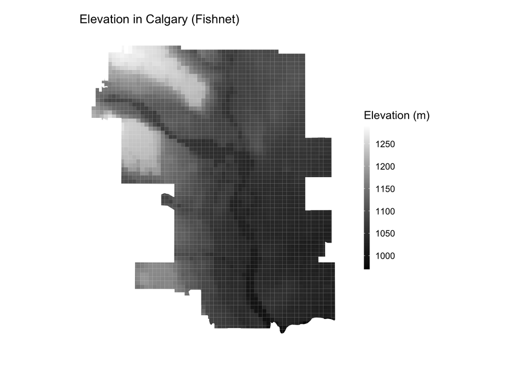

```r
#Elevation
filtered_data <- Calgary %>%
  filter(Elev >= 800 & Elev <= 1300)

ggplot() +
  geom_sf(data = filtered_data, aes(fill = Elev), color = "transparent") +
  scale_fill_gradient(low = "black", high = "white",
                      breaks = seq(900, 1300, length.out = 9),
                      labels = c("900", "950", "1000", "1050", "1100", "1150", "1200", "1250", "1300"),
                      name = "Elevation (m)") +
  labs(title = "Elevation in Calgary (Fishnet)") +
  mapTheme
```

### Impervious Surfaces

We predict that the more impervious surfaces there are, the most likely it is to flood in these regions. These surfaces are typically found in dense urban areas where impermeable materials like concrete and asphalt are being used, preventing water from entering the groundwater system and thus pooling on the impervious surfaces.

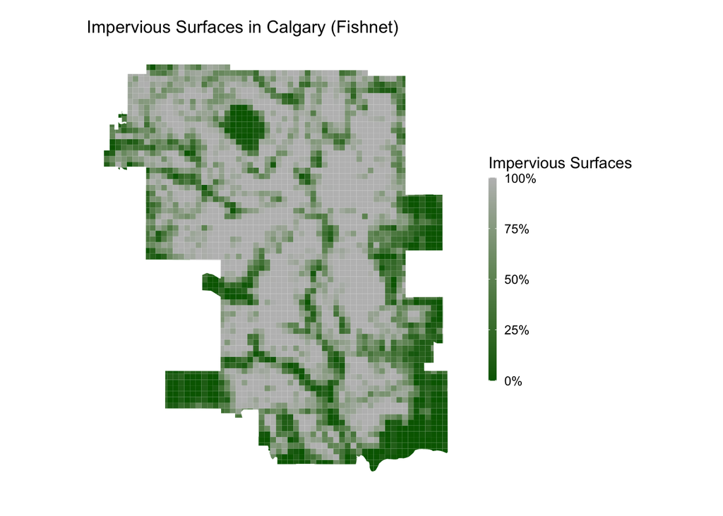

```r
#Impervious surfaces
ggplot() +
  geom_sf(data = Calgary, aes(fill = Imperv), color = "transparent") +
  scale_fill_gradient(low = "dark green", high = "grey",
                      breaks = seq(0, 1, length.out = 5),
                      labels = c("0%", "25%", "50%", "75%", "100%"),
                      name = "Impervious Surfaces") +
  labs(title = "Impervious Surfaces in Calgary (Fishnet)") +
  mapTheme
```

### Distance from Water

We also predict that the closer a cell is to a body of water, the more likely it is to flood. This variable is especially important because, in the event of inundation, the areas that are closest to an existing body of water are the first to flood.

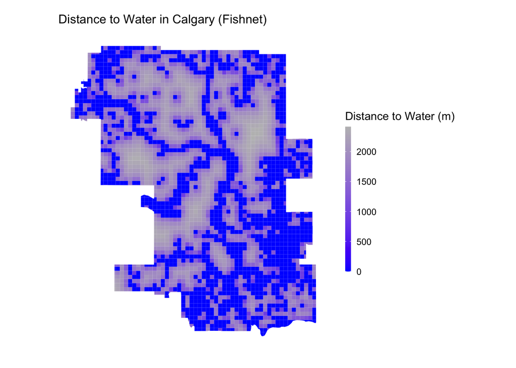

```r
#Water Distance
ggplot() +
  geom_sf(data = Calgary, aes(fill = log_DistWat), color = "transparent") +
  scale_fill_gradient(low = "blue", high = "grey",
                      breaks = seq(0, 8, length.out = 6),
                      labels = c("0", "500", "1000", "1500", "2000", "2500"),
                      name = "Distance to Water (m)") +
  labs(title = "Distance to Water in Calgary (Fishnet)") +
  mapTheme
```

### Flow Accumulation

The final variable that we used for our model was flow accumulation, where we hypothesized that the higher the flow accumulation in the area of a stream or river, the more likely this area was to flood. In areas that are downstream of a body of water, we predict that greater amounts of water will be traveling to areas with a high flow accumulation, thus leading to a greater chance of flooding.

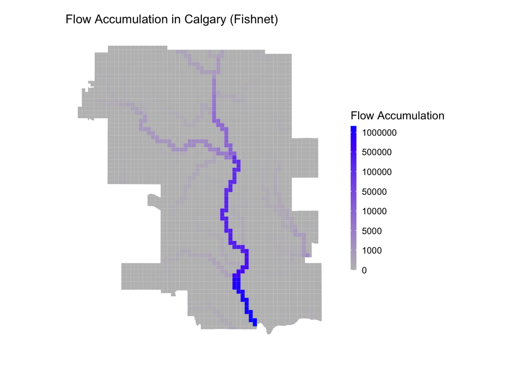

```r
#Flow accumulation

ggplot() +
  geom_sf(data = filtered_data, aes(fill = FloAcc), color = "transparent") +
  scale_fill_gradient(low = "grey", high = "blue",
                      breaks = seq(0, 1500000, length.out = 9),
                      labels = c("0", "1000", "5000", "10000", "50000", "100000", "500000", "1000000", "1500000"),
                      name = "Flow Accumulation") +
  labs(title = "Flow Accumulation in Calgary (Fishnet)") +
  mapTheme
```

# Creating Plot Variables

In this step, we defined our variables and created plots showing the correlation of each in the event of inundation. We used the known inundation from Calgary to see how each variable impacts flooding. This helps us see if our variables have enough of a correlation to be used in a model to successfully predict flooding in a comparable city using the same variables.

## Selecting the Columns we want for the model

```r
CalgaryPlotVariables <-
  Calgary %>%
  as.data.frame() %>%
  select(Inundation, Imperv, Elev, DistanceTo, FloAcc) %>%
  gather(variable, value, -Inundation)
```

```r
Calgary %>% as.data.frame() %>%
    select(Inundation, Imperv, Elev, DistanceTo, FloAcc) %>%
    pivot_longer(cols = -Inundation)
```

[output not shown]

## Graphing each variable in relation to inundation

Here we have graphed all four variables’ means by inundation or no inundation. The average distance to water for inundated cells is extremely low, as the areas near the river were the first to flood. Because the elevation difference in Calgary is not very drastic, the chart indicating elevation as a factor of inundation is not vastly different. However, we can see that areas that were inundated did have a lower elevation, validating our hypothesis. In cells that were inundated, flow accumulation was extremely high compared to areas that were not inundated. Finally, we can see that the average percent of impervious surfaces is higher for cells that were not inundated. This is contrary to our hypothesis that greater amounts of impervious surfaces would lead to more flooding. This is likely because many of Calgary’s impervious surfaces are concentrated far from the Bow River. This suggests that impervious surfaces may only impact flooding when they are close to water and at a lower elevation.

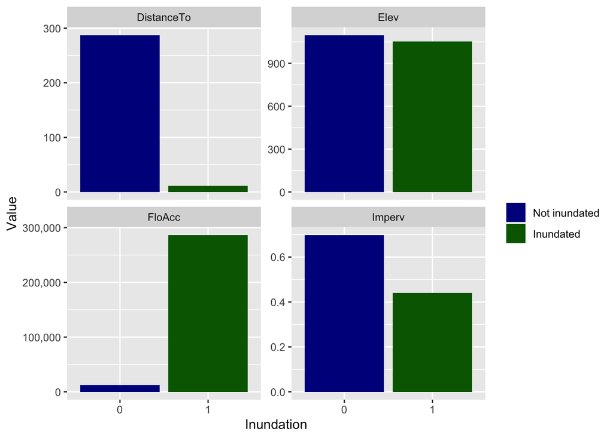

```r
ggplot(CalgaryPlotVariables %>%
         group_by(Inundation, variable) %>%
         summarize(mean = mean(value))) +
     geom_bar(aes(as.factor(Inundation),
                  mean,
                  fill=as.factor(Inundation)),
              stat="identity") +
     facet_wrap(~variable, scales = "free_y") +
     scale_fill_manual(values = c("dark blue", "dark green"),
                      labels = c("Not inundated","Inundated"),
                      name = "") +
    labs(x="Inundation", y="Value") +
scale_y_continuous(labels = scales::comma)
```

### Confirming the graphs above are correctly labeled

```r
mean_Imperv_inundation1 <- CalgaryPlotVariables %>%
filter(Inundation == 1) %>%
group_by(variable) %>%
summarize(mean_Imperv = mean(value))
```

### Violin Plots

```r
ggplot(CalgaryPlotVariables) +
     geom_violin(aes(x = as.factor(Inundation),
                  y = value, fill = as.factor(Inundation))) +
     facet_wrap(~variable, scales = "free") +
     labs(x="Preserved", y="Value") +
     scale_fill_manual(values = c("dark blue", "dark green"),
     labels = c("Not Inundated","Inundated"), name = "") +
     labs(x="Inundated", y="Value") +
  plotTheme
```

[output not shown]

# Model building

After all of the data and variables have been primed and validated, we are ready to build our model.

## Partition training and test sets

First, we are breaking the data up into test sets and training sets. The training set will be used to train our model to run, and the test set will be used to ensure that it works. We chose a 70/30 split of our full Calgary data between our training and testing set, respectively.

```r
set.seed(3456)
trainIndex <- createDataPartition(Calgary$Inundation, p = .70,
                                  list = FALSE,
                                  times = 1)

CalgaryTrain <- Calgary[ trainIndex,]
CalgaryTest  <- Calgary[-trainIndex,]
```

## Making a binomial model

We then made a binomial model to identify the significance of each variable in our model.

```r
CalgaryModel <- glm(Inundation ~ .,
                    family="binomial"(link="logit"), data = CalgaryTrain %>%
                                                            as.data.frame() %>%
                                                            select(Inundation, Imperv, Elev, DistanceTo, FloAcc))
summary(CalgaryModel)
```

```
##
## Call:
## glm(formula = Inundation ~ ., family = binomial(link = "logit"),
##     data = CalgaryTrain %>% as.data.frame() %>% select(Inundation,
##         Imperv, Elev, DistanceTo, FloAcc))
##
## Deviance Residuals:
##     Min       1Q   Median       3Q      Max
## -2.3642  -0.4741  -0.1869  -0.0213   3.3963
##
## Coefficients:
##               Estimate Std. Error z value Pr(>|z|)
## (Intercept)  8.220e+00  2.163e+00   3.799 0.000145 ***
## Imperv      -8.437e-01  2.472e-01  -3.413 0.000643 ***
## Elev        -9.011e-03  2.045e-03  -4.407 1.05e-05 ***
## DistanceTo  -9.718e-03  1.736e-03  -5.597 2.18e-08 ***
## FloAcc       4.220e-06  5.687e-07   7.420 1.17e-13 ***
## ---
## Signif. codes:  0 '***' 0.001 '**' 0.01 '*' 0.05 '.' 0.1 ' ' 1
##
## (Dispersion parameter for binomial family taken to be 1)
##
##     Null deviance: 1385.74  on 2176  degrees of freedom
## Residual deviance:  925.42  on 2172  degrees of freedom
## AIC: 935.42
##
## Number of Fisher Scoring iterations: 9
```

## Model validation

Finally, we validated our model using predict functions that allow us to predict the probability of a test set cell being inundated according to the variables defined by our model.

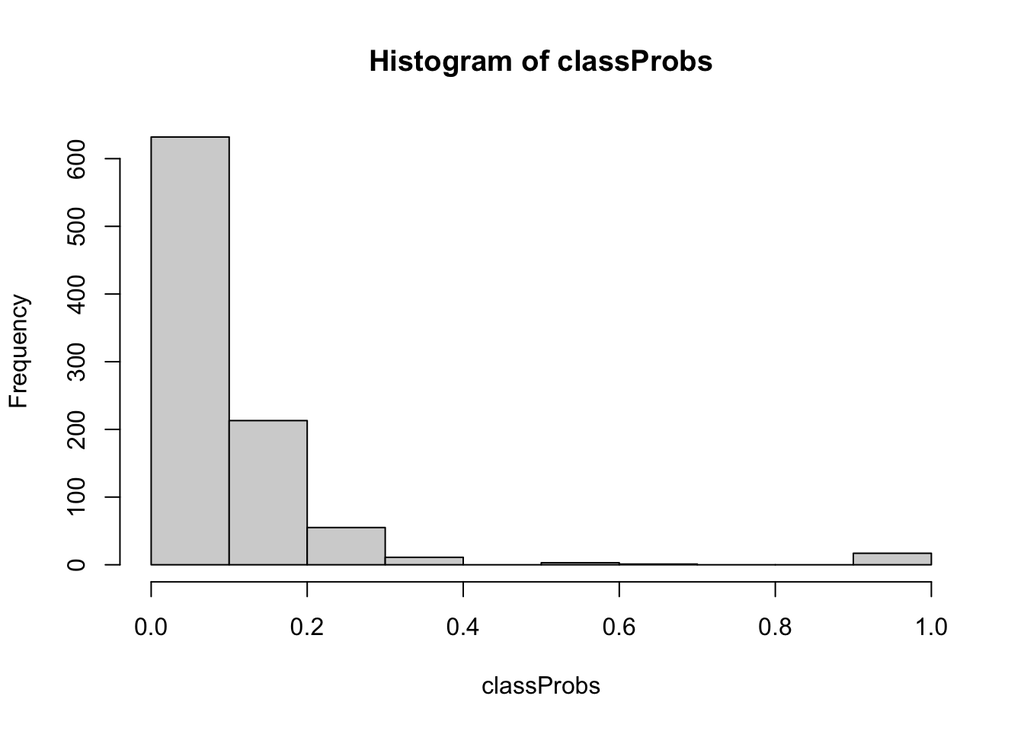

```r
classProbs <- predict(CalgaryModel, CalgaryTest, type="response")

hist(classProbs)
```

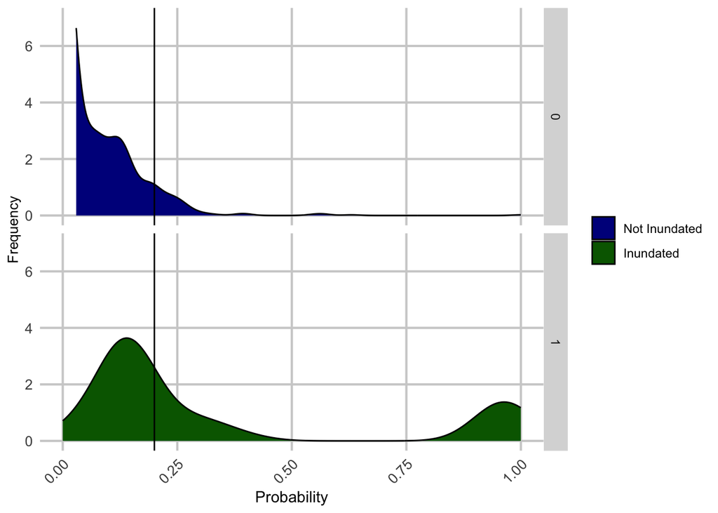

```r
testProbs <- data.frame(obs = as.numeric(CalgaryTest$Inundation),
                        pred = classProbs)

ggplot(testProbs, aes(x = pred, fill=as.factor(obs))) +
  geom_density() +
  facet_grid(obs ~ ., scales = "free_y") +
  ylim(0,7)+
  xlab("Probability") +
  ylab("Frequency")+
  geom_vline(xintercept = .2) +
  scale_fill_manual(values = c("dark blue", "dark green"),
                      labels = c("Not Inundated","Inundated"),
                      name = "")+
  plotTheme
```

### Confusion metrics

A false negative indicates that the model predicts there will be no inundation, but there is. This could impact a region’s preparation for flooding and lead to damaged infrastructure that was built with little threat of inundation in mind. Because of this, we chose a probability that resulted in fewer false negatives so that the model could be used with more confidence, specifically for the areas that are presumed to be at no risk of inundation.

Sensitivity in a model is the true positive rate. This measures the number of cells our model correctly identified as inundated. In this case, sensitivity is 0.3611, meaning that our model was only 36% accurate in predicting where inundation actually occurred. Similarly, specificity is the true negative rate - i.e. where the model correctly identified cells as being not inundated. Our model’s specificity was 0.92907, meaning that it predicted non-inundated cells over 92% of the time. Thus, our model is much better at predicting where inundation will not occur, and not good at identifying where inundation actually occurred.

```r
testProbs$predClass  = ifelse(testProbs$pred > .2 ,1,0)

caret::confusionMatrix(reference = as.factor(testProbs$obs),
                       data = as.factor(testProbs$predClass),
                       positive = "1")
```

```
## Confusion Matrix and Statistics
##
##           Reference
## Prediction   0   1
##          0 799  46
##          1  61  26
##
##                Accuracy : 0.8852
##                  95% CI : (0.863, 0.905)
##     No Information Rate : 0.9227
##     P-Value [Acc > NIR] : 1.0000
##
##                   Kappa : 0.2649
##
##  Mcnemar's Test P-Value : 0.1759
##
##             Sensitivity : 0.36111
##             Specificity : 0.92907
##          Pos Pred Value : 0.29885
##          Neg Pred Value : 0.94556
##              Prevalence : 0.07725
##          Detection Rate : 0.02790
##    Detection Prevalence : 0.09335
##       Balanced Accuracy : 0.64509
##
##        'Positive' Class : 1
##
```

*Predicted = 0, Observed = 0 —> True Negative*

*Predicted = 1, Observed = 1 —> True Positive*

*Predicted = 1, Observed = 0 —> False Positive*

*Predicted = 0, Observed = 1 —> False Negative*

### ROC Curve

An ROC (Receiver Operating Characteristic) curve is a graphical representation of the performance of our model. It illustrates the trade-off between the true positive and true negative rates. The curve itself tells us the model’s ability to distinguish between these two classes, which, in our case, the model seems to do well.

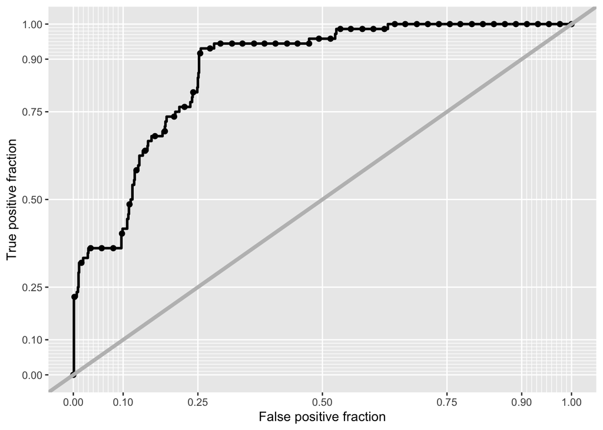

```r
ggplot(testProbs, aes(d = obs, m = pred)) +
  geom_roc(n.cuts = 50, labels = FALSE) +
  style_roc(theme = theme_grey) +
  geom_abline(slope = 1, intercept = 0, size = 1.5, color = 'grey')
```

```r
auc(testProbs$obs, testProbs$pred)
```

```
## Area under the curve: 0.8679
```

### Cross validation

We are now testing the power of our model on randomly generated test sets through cross-validation. The randomized data sets test our model in how well it handles different test data. The accuracy metric seen as a result of the cvFit shows the accuracy across all test sets randomly run through the model. On average, this accuracy has been around 92% for our model.

```r
ctrl <- trainControl(method = "cv",
                     number = 100,
                     p = 0.7,
                     savePredictions = TRUE)

cvFit <- train(as.factor(Inundation) ~ .,  data = Calgary %>%
                                                as.data.frame() %>%
                                                select(Inundation, Imperv, Elev, log_DistWat, FloAcc),
               method="glm", family="binomial",
               trControl = ctrl)
cvFit
```

```
## Generalized Linear Model
##
## 3109 samples
##    4 predictor
##    2 classes: '0', '1'
##
## No pre-processing
## Resampling: Cross-Validated (100 fold)
## Summary of sample sizes: 3079, 3078, 3078, 3077, 3078, 3079, ...
## Resampling results:
##
##   Accuracy  Kappa
##   0.923875  0.2747997
```

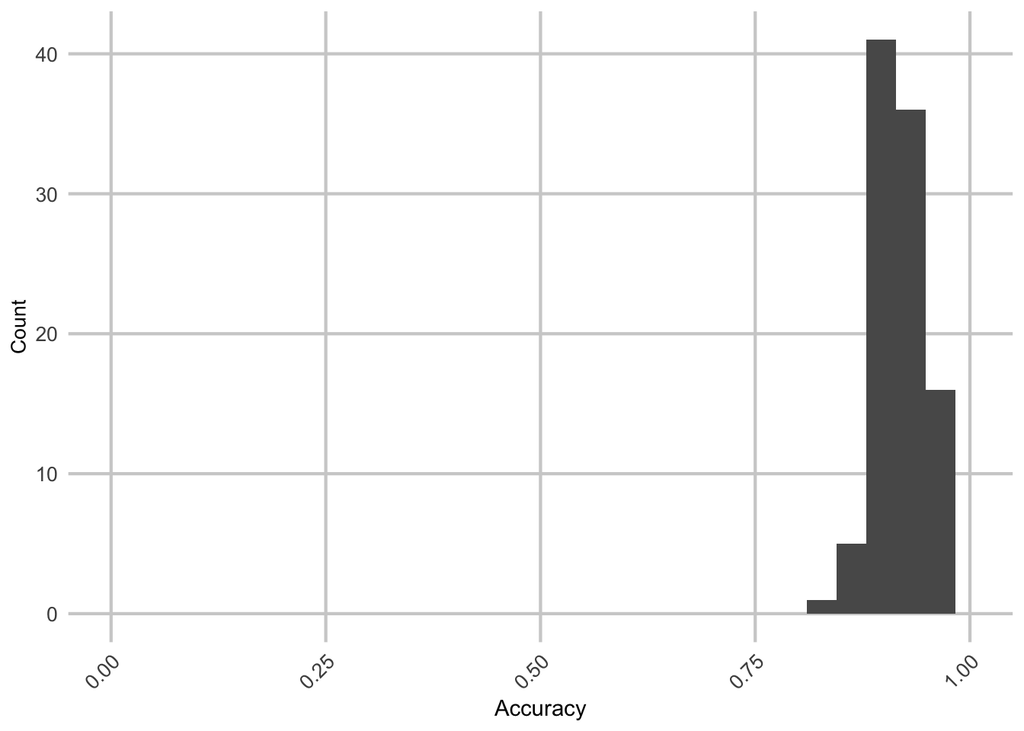

```r
ggplot(as.data.frame(cvFit$resample), aes(Accuracy)) +
  geom_histogram() +
  scale_x_continuous(limits = c(0, 1)) +
  labs(x="Accuracy",
       y="Count")+
  plotTheme
```

### Cross validation for Calgary Training Set

Here, we are doing the same for the Calgary training set.

```r
CalgaryTrain <- CalgaryTrain %>%
  mutate(log_DistWat = ifelse(DistanceTo != 0, log(DistanceTo), 0))

ctrlTrain <- trainControl(method = "cv",
                     number = 100,
                     p = 0.7,
                     savePredictions = TRUE)

cvFitTrain <- train(as.factor(Inundation) ~ .,  data = CalgaryTrain %>%
                                                as.data.frame() %>%
                                                select(Inundation, Imperv, Elev, log_DistWat, FloAcc),
               method="glm", family="binomial",
               trControl = ctrl)
cvFitTrain
```

```
## Generalized Linear Model
##
## 2177 samples
##    4 predictor
##    2 classes: '0', '1'
##
## No pre-processing
## Resampling: Cross-Validated (100 fold)
## Summary of sample sizes: 2155, 2155, 2155, 2155, 2156, 2156, ...
## Resampling results:
##
##   Accuracy   Kappa
##   0.9193779  0.271496
```

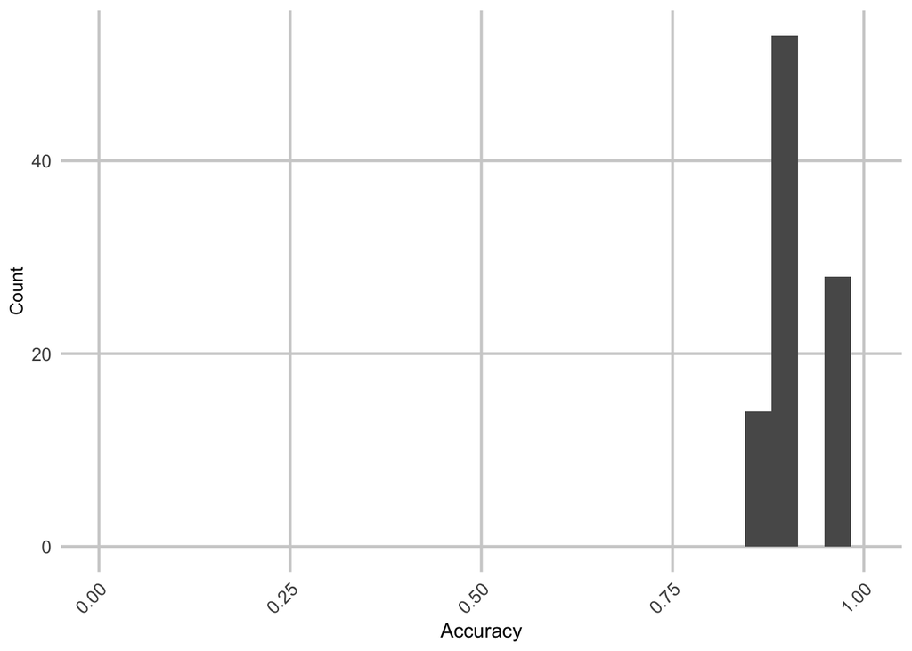

```r
ggplot(as.data.frame(cvFitTrain$resample), aes(Accuracy)) +
  geom_histogram() +
  scale_x_continuous(limits = c(0, 1)) +
  labs(x="Accuracy",
       y="Count")+
  plotTheme
```

### Map predictions

After tuning the model, we are able to run it to predict the entire dataset. The map tells us that our model predicts inundation with consideration for all of our variables in areas that are the darkest, which also happen to be areas that overlap with many of the bodies of water in Calgary. The lightest color are areas the least likely to flood.

```r
allPredictions <-
  predict(cvFit, Calgary, type="prob")[,2]

Calgary <-
  cbind(Calgary,allPredictions) %>%
  mutate(allPredictions = round(allPredictions * 100))
```

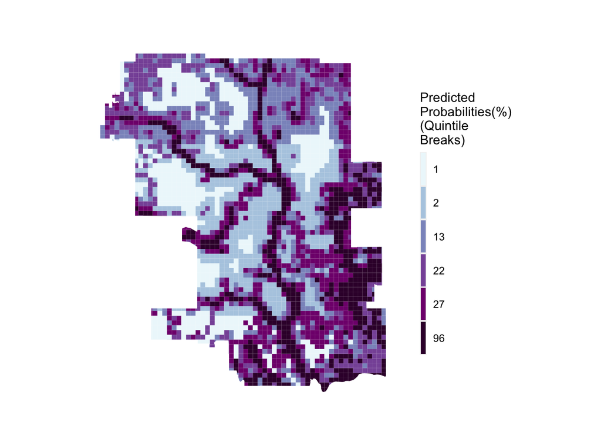

```r
 ggplot() +
    geom_sf(data=Calgary, aes(fill=factor(ntile(allPredictions,6))),
            colour=NA) +
    scale_fill_manual(values = c("#edf8fb","#b3cde3","#8c96c6","#8856a7", "#810f7c", "#3a0138"),
                      labels=as.character(quantile(Calgary$allPredictions,
                                                 c(.35,.5,.75, .9, .95, .99),
                                                 na.rm=T)),
                      name="Predicted\nProbabilities(%)\n(Quintile\nBreaks)") +
  mapTheme +
  labs(title="")
```

### Map predictions for Calgary Training Set

Here, we are running the map predictions on the Calgary training set only.

```r
allPredictionsTrain <-
  predict(cvFitTrain, CalgaryTrain, type="prob")[,2]

CalgaryTrain <-
  cbind(CalgaryTrain,allPredictionsTrain) %>%
  mutate(allPredictionsTrain = round(allPredictionsTrain * 100))
```

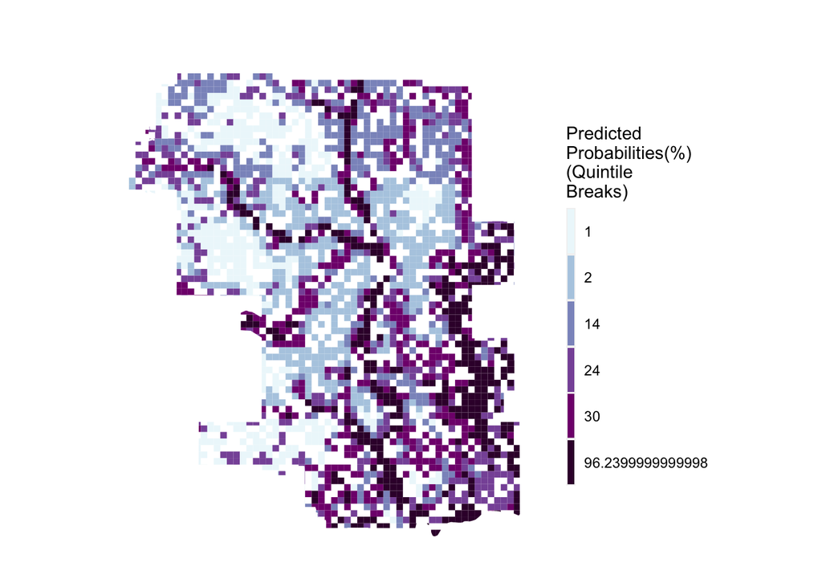

```r
 ggplot() +
    geom_sf(data=CalgaryTrain, aes(fill=factor(ntile(allPredictionsTrain,6))),
            colour=NA) +
    scale_fill_manual(values = c("#edf8fb","#b3cde3","#8c96c6","#8856a7", "#810f7c", "#3a0138"),
                      labels=as.character(quantile(CalgaryTrain$allPredictionsTrain,
                                                 c(.35,.5,.75, .9, .95, .99),
                                                 na.rm=T)),
                      name="Predicted\nProbabilities(%)\n(Quintile\nBreaks)") +
  mapTheme +
  labs(title="")
```

### Overlaying Inundation Data with Model Predictions

Because we have inundation data for Calgary, we can overlay this information with our model’s prediction and visibly see how accurate it was. After analyzing, it seems that the model predicted the southern portion of the main river through Calgary accurately, as well as some tributaries that flooded in the past. However, there are standing bodies of water in the eastern portion of the city that our model predicted inundation for, but the existing inundation data says otherwise. This could be the source of some of the errors we had previously calculated.

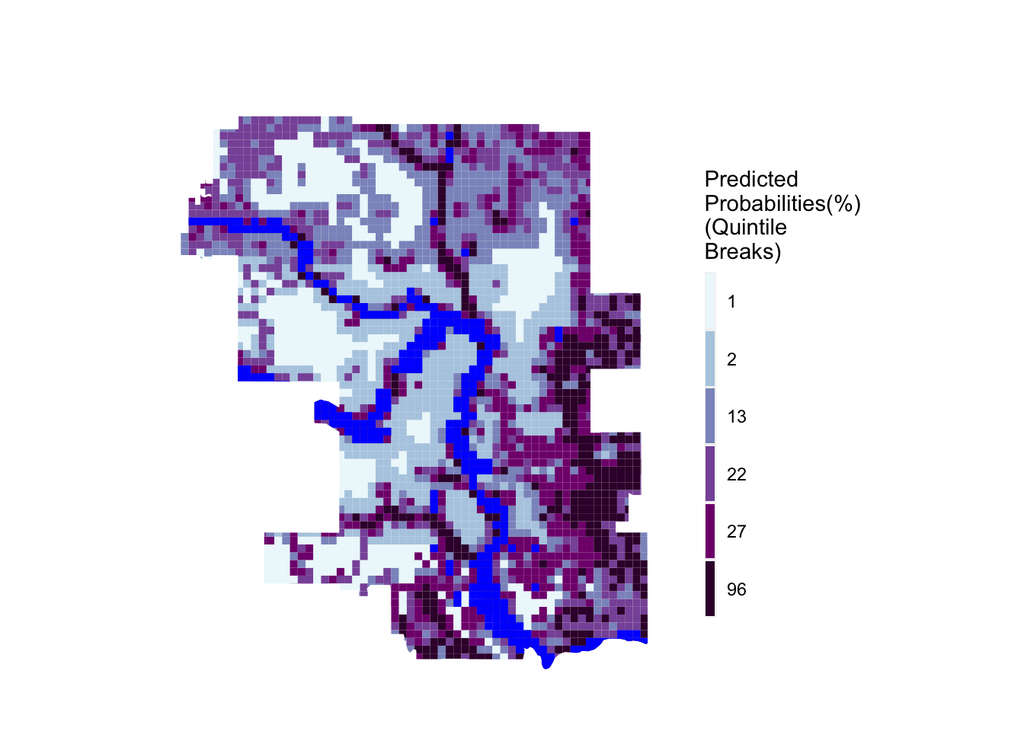

```r
 ggplot() +
  geom_sf(data=Calgary, aes(fill=factor(ntile(allPredictions,6))), colour=NA) +
  scale_fill_manual(values = c("#edf8fb","#b3cde3","#8c96c6","#8856a7", "#810f7c", "#3a0138"),
                    labels=as.character(quantile(Calgary$allPredictions,
                                                 c(.35,.5,.75, .9, .95, .99),
                                                 na.rm=T)),
                    name="Predicted\nProbabilities(%)\n(Quintile\nBreaks)") +
  geom_sf(data=Calgary  %>%
               filter(Inundation == 1),
               fill="blue",colour=NA) +
  mapTheme +
  labs(title="",
       subtitle="")
```

### Confusion metrics for Calgary (all)

The map of the confusion metrics show us where the model accurately predicted either inundation or no inundation (a true positive or true negative, respectively), as well as where it predicted incorrectly. The false positives are areas where the model predicted that there would be inundation, but there wasn’t. Many of these cells are either north of the largest chunk of the river, or on the eastern portion of Calgary where many standing bodies of water are. The false negatives are areas where flooding was not predicted, but it occurred. Most of these areas are on the western tributary of the river. The reason that the model may not have predicted this correctly may be due to the elevation in these areas or the little flow accumulation in those portions of the river.

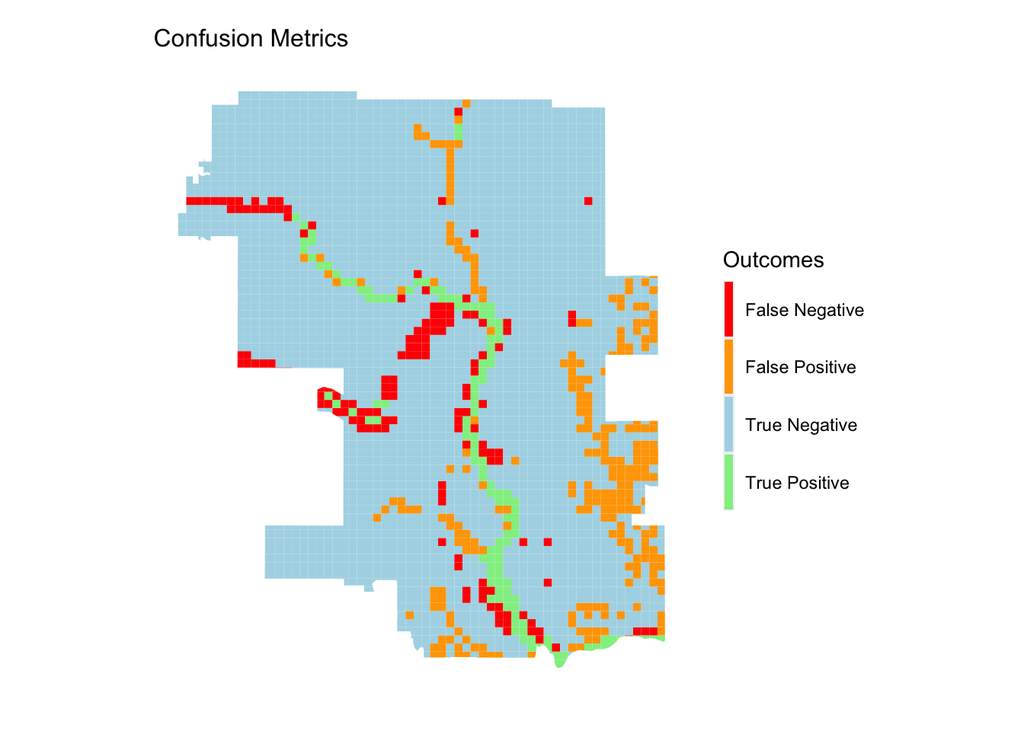

```r
Calgary %>%
  mutate(confResult=case_when(allPredictions < 20 & Inundation==0 ~ "True Negative",
                              allPredictions >= 20 & Inundation==1 ~ "True Positive",
                              allPredictions < 20 & Inundation==1 ~ "False Negative",
                              allPredictions >= 20 & Inundation==0 ~ "False Positive")) %>%
  ggplot()+
  geom_sf(aes(fill = confResult), color = "transparent")+
  scale_fill_manual(values = c("Red","Orange","Light Blue","Light Green"),
                    name="Outcomes")+
  labs(title="Confusion Metrics") +
  mapTheme
```

### Confusion metrics for Calgary Training Set

We run the same confusion metrics for the Calgary training set.

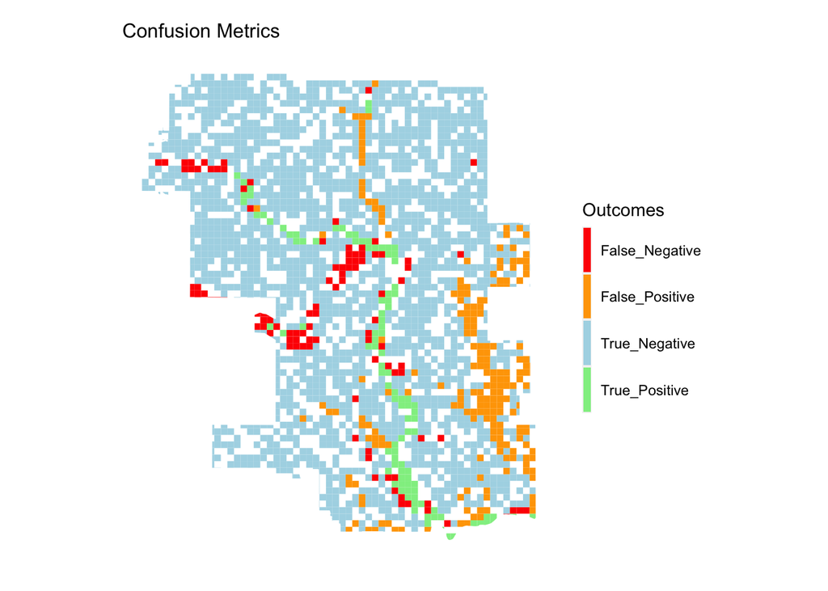

```r
CalgaryTrain %>%
  mutate(confResult=case_when(allPredictionsTrain < 20 & Inundation==0 ~ "True_Negative",
                              allPredictionsTrain >= 20 & Inundation==1 ~ "True_Positive",
                              allPredictionsTrain < 20 & Inundation==1 ~ "False_Negative",
                              allPredictionsTrain >= 20 & Inundation==0 ~ "False_Positive")) %>%
  ggplot()+
  geom_sf(aes(fill = confResult), color = "transparent")+
  scale_fill_manual(values = c("Red","Orange","Light Blue","Light Green"),
                    name="Outcomes")+
  labs(title="Confusion Metrics") +
  mapTheme
```

# Testing Model on Comparable City - Ottawa

Now that the model has been tested and verified, we can use it to predict inundation in a comparable city. We chose Ottawa, Ontario (CA) because of its similar climate and geography. Both cities have similar hydrology, elevation changes, and climates. Because of these similarities, we can hope that our model will accurately predict Ottawa’s inundation.

## Cleaning dataset

```r
Ottawa <- Ottawa %>%
rename(Imperv = MEAN, Elev = MAX, DistWat = MIN, FloAcc = MAX_1)

Ottawa <- Ottawa %>%
  mutate(DistanceTo = DistWat * 82242)

Ottawa <- Ottawa %>%
  mutate(log_DistWat = ifelse(DistanceTo != 0, log(DistanceTo), 0))
```

## Running Ottawa in the Model

Using the same model and variables for Ottawa, we predict inundation concentrated around the Ottawa River - along the northern border of the city - and the Rideau River, which flows north/south through the city. This aligns with expectations about perceived inundation, which is along the existing river and in low-elevation areas. In the future, we should validate our Ottawa predictions using historic inundation data.

```r
allPredictionsOttawa <-
  predict(cvFit, Ottawa, type="prob")[,2]

Ottawa <-
  cbind(Ottawa,allPredictionsOttawa) %>%
  mutate(allPredictionsOttawa = round(allPredictionsOttawa * 100))
```

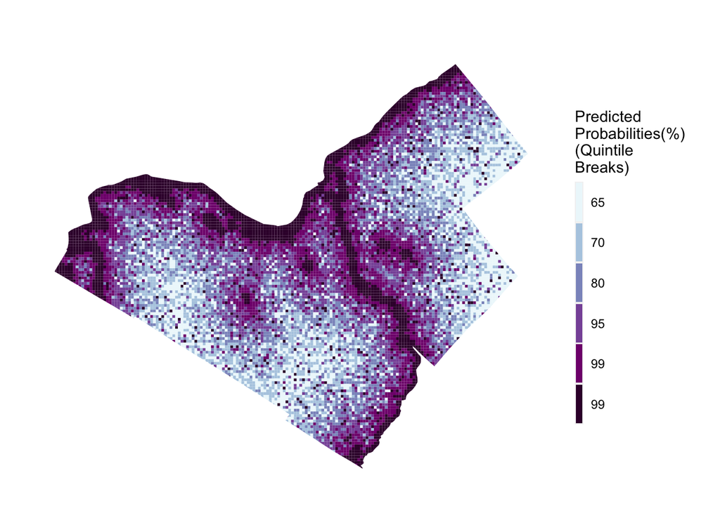

```r
 ggplot() +
    geom_sf(data=Ottawa, aes(fill=factor(ntile(allPredictionsOttawa,6))),
            colour=NA) +
    scale_fill_manual(values = c("#edf8fb","#b3cde3","#8c96c6","#8856a7", "#810f7c", "#3a0138"),
                      labels=as.character(quantile(Ottawa$allPredictionsOttawa,
                                                 c(.35,.5,.75, .9, .95, .99),
                                                 na.rm=T)),
                      name="Predicted\nProbabilities(%)\n(Quintile\nBreaks)") +
  mapTheme +
  labs(title="")
```

# Video

https://youtu.be/xSNGkc8D_ug